# pres_Kalman slides

## Kalman filter for control

### MEC 560: Advaced control systems

#### Vivek Yadav

### Kalman filter: Main idea

- Estimate future states based on system dynamics
- Update state estimates after getting measurement
- Find gain that minimizes error between true expected state and estimated state.

[figure not shown]

### Discrete Kalman filter: Derivation

System dynamics

$$ X_{k+1} = AX_{k} + Bu_{k} + Fw_{k} $$

- \( w_k \) is uncertainity in the system dynamics and is represented as a Gaussian process, with covariance \( E(w_k w_k^T ) = Q \).
- State variables \( X_k \) are also modeled as mutually independent Gaussian processes with covariance \( P_k \)
- Initial conditions are now given as, \(X(0) = X_0 \) and covariance \( P_0 \).

### Measurement

$$ Y_k = CX_k + Du_k + v_k $$

- \( v_k \) is uncertainity in the measurement with covariance \( E(v_k v_k^T ) = R \).

#### System dynamics

$$ X_{k+1} = AX_{k} + Bu_{k} + Fw_{k} $$

- \( E(w_k w_k^T ) = Q \), covariance \( P_k \), \(X(0) = X_0 \) and covariance \( P_0 \).

#### Measurement

$$ Y_k = CX_k + Du_k + v_k $$

- \( v_k \) is uncertainity in the measurement with covariance \( E(v_k v_k^T ) = R \).

*By repeating the process of measurement and state propogation successively, states can be estimates.*

### Notations

- \( X_{k|k} \) State estimate after measurement update
- \( X_{k+1|k} \) State estimate using system dynamics from \( k \) to \( k + 1 \).
- \( \bar{X} \) represents expected value of \( X \).

### 1. State propogation

System dynamics are given by,

$$ X_{k+1} = AX_{k} + Bu_{k} + F w_{k} $$

To separate the state estimates before and after measurement, we define, \( X_{k|k} \) as estimate after measurement at step \( k \).

\( X_{k+1|k} \) is the state estimate after following system dynamics. Therefore the expected future value of the state are given by,

$$ E(X_{k+1|k} ) = AE(X_{k|k} ) + BE(u_k) + E(F w_k) $$$$ \hat{X}_{k+1|k} = A\hat{X}_{k|k} + B u_k $$

The error between state estimate and expected value, before getting measurement is represented as,

$$ X_{k+1|k} - \bar{X}_{k+1|k} = AX_{k|k} + Bu_k + F w_k -( A\bar{X}_{k|k} + Bu_k ) $$$$ e_{k+1|k} = X_{k+1|k} - \bar{X}_{k+1|k} = Ae_{k|k} + F w_k$$

Therefore, the covariance of state before getting measurement is given by,

$$ P_{k+1|k} = E(e_{k+1|k} e_{k+1|k}^{-T}) = P( (X_{k+1|k}- \bar{X}_{k+1|k})(X_{k+1|k} - \bar{X}_{k+1|k})^T) $$$$ P_{k+1|k} = A E(e_{k|k} e_{k|k}^T) A^T + E(Fw_k w_k^TF^T)$$

Therefore, the error covariance propogation is given by,

$$ P_{k+1|k} = A P_{k|k} A^T + FQF^T . $$

### 2. Update

Update covariance of state estimates after getting the measurement. The measurement are given by,

$$ Y_{k+1} = CX_{k+1|k} + Du_{k+1} + v_{k+1} $$

The expected value of measurement is given by,
$$ \hat{Y}_{k+1} = C \hat{X}_{k+1|k}+ Du_{k+1} . $$

The error between state estimate and mean is given by,

$$ Y_{k+1} - \hat{Y}_{k+1}= CX_{k+1|k} + Du_{k+1} + v_{k+1} - ( C \hat{X}_{k+1|k} + Du_{k+1})$$$$ e_{Y,k+1} = Ce_{k+1|k} + v_{k+1} $$

The covariance of measurement error before getting measurement is given by,

$$ E(e_{Y,k+1} e_{Y,k+1}^T) = E((Ce_{k+1|k} + v_{k+1})(Ce_{k+1|k} + v_{k+1})^T) $$$$ E(e_{Y,k+1} e_{Y,k+1}^T) = E((Ce_{k+1|k} + v_{k+1})(e_{k+1|k}^TC^T + v_{k+1}^T)) $$$$ = CP_{k+1|k}C^T + R $$

- State update after measurement (same as observer update),

$$ \hat{X}_{k+1|k+1} = \hat{X}_{k+1|k}+ K_{k+1}(Y_{k+1} - ( C \hat{X}_{k+1|k} + Du_{k+1}) )$$$$ \hat{X}_{k+1|k+1} = \hat{X}_{k+1|k} + K_{k+1}e_{Y,k+1}$$$$ \hat{X}_{k+1|k+1} = \hat{X}_{k+1|k} + K_{k+1}C e_{k+1|k} +K_{k+1}v_{k+1} $$

Choose a gain so the error between posterior state estimate and actual state is minimum.

$$ X_{k+1}- \hat{X}_{k+1|k+1} = X_{k+1}- \hat{X}_{k+1|k} - K_{k+1}C e_{k+1|k} -K_{k+1}v_{k+1} $$$$ e_{k+1|k+1} = (I - K_{k+1}C) e_{k+1|k} - K_{k+1} v_{k+1} $$

The posterior error covariance becomes

$$ P_{k+1|k+1} = E( e_{k+1|k+1} e_{k+1|k+1}^T ) $$$$= E \left( ( (I - K_{k+1}C) e_{k+1|k} - K_{k+1} v_{k+1} ) ( (I - K_{k+1}C) e_{k+1|k} - K_{k+1}v_{k+1} ) ^T \right)$$$$= (I - K_{k+1}C) E (e_{k+1|k} e_{k+1|k}^T) (I - K_{k+1}C)^T + K_{k+1} E(v_{k+1} v_{k+1}^T) K_{k+1}^T$$$$P_{k+1|k+1} = (I - K_{k+1}C) P_{k+1|k} (I - K_{k+1}C)^T + K_{k+1}R K_{k+1}^T$$$$P_{k+1|k+1} = (I - K_{k+1}C) P_{k+1|k} (I - K_{k+1}C)^T + K_{k+1} R K_{k+1}^T$$$$P_{k+1|k+1} = P_{k+1|k} - K_{k+1}C P_{k+1|k} - P_{k+1|k} C^T K_{k+1}^T + K_{k+1} (C P_{k+1|k} C^T + R) K_{k+1}^T $$

The trace of covariance matrix is the error between state estimate and update from measurement, therefore, the gain matrix that minimizes the covariance matrix is the optimal solution.

$$ \frac{\partial tr(P_{k+1|k+1} )}{\partial K_{k+1} } = -2 (CP_{k+1|k})^T + 2K_{k+1} (C P_{k+1|k} C^T + R) = 0$$

Therefore,

$$ K_{k+1} = P_{k+1|k}C^T(C P_{k+1|k} C^T + R)^{-1} $$

Substituting \( K_{k+1} \) in expression for posterior covariance gives,

$$P_{k+1|k+1} = P_{k+1|k} - K_{k+1}C P_{k+1|k} = ( I - K_{k+1}C ) P_{k+1|k} $$

### Final form of Kalman filter

#### 1. State propogation

$$ \bar{X}_{k+1|k} = A\bar{X}_{k|k} + Bu_k $$$$ P_{k+1|k} = A P_{k|k} A^T + FQF^T . $$

#### 2. Measurement update

$$ e_{Y,k+1} = y(k+1) - ( C \hat{X}_{k+1|k} + Du_{k+1})$$$$ S_{k+1} = (C P_{k+1|k} C^T + R) $$$$ K_{k+1} = P_{k+1|k} C^TS_{k+1}^{-1}$$$$ \hat{X}_{k+1|k+1} = \hat{X}_{k+1|k} + K_{k+1}e_{Y,k+1}$$$$P_{k+1|k+1} = ( I - K_{k+1}C ) P_{k+1|k} $$

### Kalman filter: Example 1

Consider the system give

$$ \ddot{X} = u $$

with measurement \( y = X \). We wish to develop an observer such that the states of the observer \( \hat{X} \rightarrow X \).

We approximate this system as follows,

$$ X_1(t+1) = X_1(t) + \delta t X_2 $$$$ X_2(t+1) = \delta t u $$

The measurement is approximated as

$$ y = X + v $$

where \( v \) is a Gaussian process with mean 0, and variance \( 10^{-8} \). Note as the system is determinitistic, we use a very low value of measurement covariance \( R \). As we know the system completely, we have \( F = [0~0]^T \).

```matlab
clc
close all
clear all


A = [0 1 ; 0 0];
B = [0 ; 1];
dt = 0.001;

Ad = eye(2) + dt*[0 1 ; 0 0];
Bd = dt*B;

C = [1 0];
R = 1e-8;
F = [0;0];
Q = 0;
P_pl = eye(2);
X_hat_0 = [0;0];

X_0 = [1;0];
```

```matlab
X(:,1)= X_0;
Y(1) = C*X(:,1);
t(1) = 0;
X_hat(:,1)= X_hat_0;

for i = 1:2000
    u = 1;

    t(i+1) = t(i)+dt;

    % True process
    X(:,i+1)=Ad * X(:,i) + Bd*u;
    Y(i+1) = C*X(:,i+1)+sqrt(R)*randn;

    P_mi = Ad*P_pl*Ad' + F*Q*F';
    X_hat(:,i+1)=Ad * X_hat(:,i) + Bd*u;

    Y_hat(i+1) = C*X_hat(:,i+1);

    e_Y  = Y(i+1) - Y_hat(i+1);
    S = C*P_mi*C'+R;
    K = P_mi*C'*inv(S);
    P_pl = (eye(2) - K*C)*P_mi;
    X_hat(:,i+1)=X_hat(:,i+1) + K*e_Y;
end
```

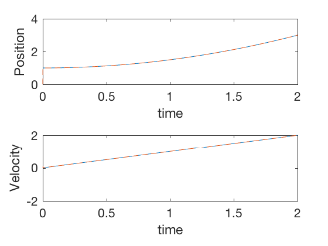

```matlab
figure;
subplot(2,1,1)
plot(t,X(1,:),t,X_hat(1,:),'--')
xlabel('time')
ylabel('Position')

subplot(2,1,2)
plot(t,X(2,:),t,X_hat(2,:),'--')
xlabel('time')
ylabel('Velocity')
```

### Kalman filter: Example 2, noisy measurement, position measurement only

Consider the system give

$$ \ddot{X} = u $$

with measurement \( y = X \). We wish to develop an observer such that the states of the observer \( \hat{X} \rightarrow X \).

We approximate this system as follows,

$$ X_1(t+1) = X_1(t) + \delta t X_2 $$$$ X_2(t+1) = \delta t u $$

The measurement is approximated as

$$ y = X + v $$

where \( v \) is a Gaussian process with mean 0, and variance \( 1 \).

```matlab
clc
close all
clear all


A = [0 1 ; 0 0];
B = [0 ; 1];
dt = 0.001;

Ad = eye(2) + dt*[0 1 ; 0 0];
Bd = dt*B;

F = [0;0];
C = [1 0];
R = 1;
Q = 0;
P_pl = eye(2);
X_hat_0 = [0;0];

X_0 = [1;0];
```

```matlab
X(:,1)= X_0;
Y(1) = C*X(:,1);
t(1) = 0;
X_hat(:,1)= X_hat_0;

for i = 1:5000
    u = .5;

    t(i+1) = t(i)+dt;

    % True process
    X(:,i+1)=Ad * X(:,i) + Bd*u;
    Y(i+1) = C*X(:,i+1) + sqrt(R)*randn(size(C,1),1);

    P_mi = Ad*P_pl*Ad' + F*Q*F';
    X_hat(:,i+1)=Ad * X_hat(:,i) + Bd*u;

    Y_hat(i+1) = C*X_hat(:,i+1);

    e_Y  = Y(i+1) - Y_hat(i+1);
    S = C*P_mi*C'+R;
    K = P_mi*C'*inv(S);
    P_pl = (eye(2) - K*C)*P_mi;
    X_hat(:,i+1)=X_hat(:,i+1) + K*e_Y;
end
```

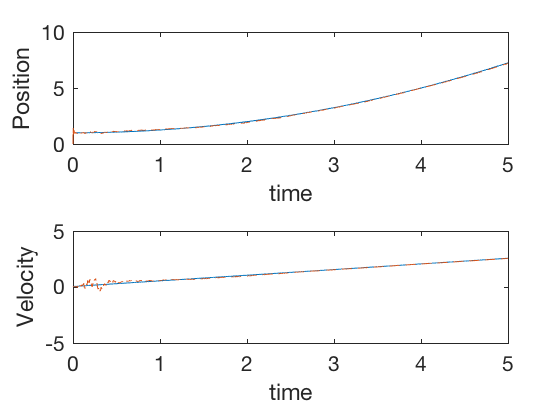

```matlab
figure;
subplot(2,1,1)
plot(t,X(1,:),t,X_hat(1,:),'--')
xlabel('time')
ylabel('Position')
axis([0 5 0 10])
subplot(2,1,2)
plot(t,X(2,:),t,X_hat(2,:),'--')
xlabel('time')
ylabel('Velocity')
axis([0 5 -5 5])
```

### Kalman filter: Example 3, noisy measurement, position and velocity measurements

Consider the system give

$$ \ddot{X} = u $$

with measurement \( y = X \). We wish to develop an observer such that the states of the observer \( \hat{X} \rightarrow X \).

We approximate this system as follows,

$$ X_1(t+1) = X_1(t) + \delta t X_2 $$$$ X_2(t+1) = \delta t u $$

The measurement is approximated as

$$ y_1 = X + v_1 $$$$ y_2 = \dot{X} + v_2 $$

where \( v \) is a Gaussian process with mean 0, and identity variance.

```matlab
clc
close all
clear all

A = [0 1 ; 0 0];
B = [0 ; 1];
dt = 0.001;

Ad = eye(2) + dt*[0 1 ; 0 0];
Bd = dt*B;

C = [1 0;
    0 1];

F = [0;0];
R = diag([1 1]);
Q = 0;
P_pl = eye(2);
X_hat_0 = [0;0];

X_0 = [1;0];
```

```matlab
X(:,1)= X_0;
Y(:,1) = C*X(:,1);
t(1) = 0;
X_hat(:,1)= X_hat_0;

for i = 1:5000
    u = .5;
    t(i+1) = t(i)+dt;

    % True process
    X(:,i+1)=Ad * X(:,i) + Bd*u;
    Y(:,i+1) = C*X(:,i+1) + sqrt(R)*randn(size(C,1),1);

    P_mi = Ad*P_pl*Ad' + F*Q*F';
    X_hat(:,i+1)=Ad * X_hat(:,i) + Bd*u;

    Y_hat(:,i+1) = C*X_hat(:,i+1);

    e_Y  = Y(:,i+1) - Y_hat(:,i+1);
    S = C*P_mi*C'+R;
    K = P_mi*C'*inv(S);
    P_pl = (eye(2) - K*C)*P_mi;
    X_hat(:,i+1)=X_hat(:,i+1) + K*e_Y;
end
```

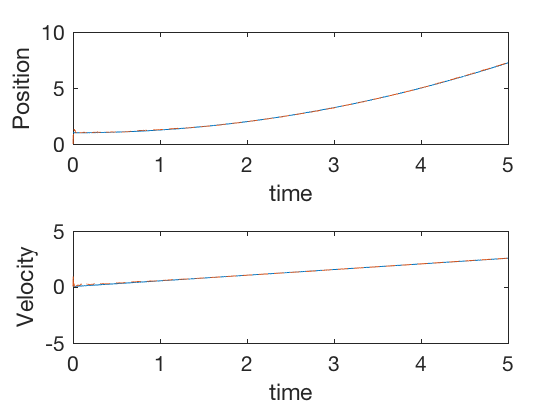

```matlab
figure;
subplot(2,1,1)
plot(t,X(1,:),t,X_hat(1,:),'--')
xlabel('time')
ylabel('Position')
axis([0 5 0 10])
subplot(2,1,2)
plot(t,X(2,:),t,X_hat(2,:),'--')
xlabel('time')
ylabel('Velocity')
axis([0 5 -5 5])
```

### Kalman filter for parameter estimation: Example 4 (position measurement only)

Consider the dynamic system given by,

$$ \dot{X_1} = X_2 + \alpha $$$$ \dot{X_2} = u $$

\( \alpha \) is unknown.

$$ X_1(t+1) = X_1(t) + \delta t X_2 + \delta t X_3 $$$$ X_2(t+1) = \delta t u $$$$ X_3(t+1) = X_3(t) + w(t) $$

where \( w(t) \) is a Gaussian process with covariance \( 10^{-4} \).

```matlab
clc
close all
clear all


A = [0 1 1; 0 0 0;0 0 0];
B = [0 ; 1;0];
dt = 0.001;

Ad = eye(3) + dt*A;
Bd = dt*B;

F = [0;0;1];

C = [1 0 0];
R = .1;
Q = diag([1e-4]);
P_pl = eye(3);

X_hat_0 = [0;0;0];
X_0 = [1;0;10];
```

```matlab
X(:,1)= X_0;
Y(:,1) = C*X(:,1);
t(1) = 0;
X_hat(:,1)= X_hat_0;

for i_sim = 1:5
    A_sim(i_sim) = X_hat(3,1);
    for i = 1:2500
        u = .5;

        t(i+1) = t(i)+dt;

        % True process
        X(:,i+1)=Ad * X(:,i) + Bd*u;
        Y(:,i+1) = C*X(:,i+1) + sqrt(R)*randn(1,1);

        % Observer model
        % Prediction based on system dynamics
        P_mi = Ad*P_pl*Ad' + F*Q*F';
        X_hat(:,i+1)=Ad * X_hat(:,i) + Bd*u;
        Y_hat(:,i+1) = C*X_hat(:,i+1);

        % Update based on measurement
        e_Y  = Y(:,i+1) - Y_hat(:,i+1);
        S = C*P_mi*C'+R;
        K = P_mi*C'*inv(S);
        P_pl = (eye(3) - K*C)*P_mi;
        X_hat(:,i+1)=X_hat(:,i+1) + K*e_Y;
    end
    X_hat(3,1) = X_hat(3,end);

end
```

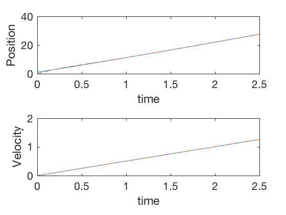

```matlab
figure;
subplot(2,1,1)
plot(t,X(1,:),t,X_hat(1,:),'--')
axis([0 2.5 0 40])
xlabel('time')
ylabel('Position')

subplot(2,1,2)
plot(t,X(2,:),t,X_hat(2,:),'--')
xlabel('time')
ylabel('Velocity')
axis([0 2.5 0 2])
```

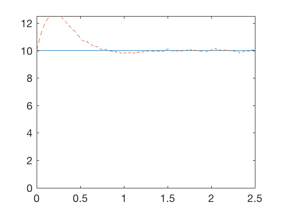

```matlab
figure;
plot(t,X(3,:),t,X_hat(3,:),'--')
axis([0 2.5 0 12.5])
```

### Kalman filter for parameter estimation: Example 5 (position and velocity measurement)

Kalman filters can be used for parameter estimation also. Consider the dynamic system given by,

$$ \dot{X_1} = X_2 + \alpha $$$$ \dot{X_2} = u $$

where \( \alpha \) is a parameter that is unknown. The measurements \( y_1 = X_1 + v_1\) and \( y_2 = X_2 + v_2\) are available, where \( v \)s are Gaussian processes with variances \( R_1 = .1 , R_2 = .1 \). We can apply Kalman filtering technique for estimating the unknown parameter.

$$ X_1(t+1) = X_1(t) + \delta t X_2 + \delta t X_3 $$$$ X_2(t+1) = \delta t u $$$$ X_3(t+1) = X_3(t) + w(t) $$

```matlab
clc
close all
clear all


A = [0 1 1; 0 0 0;0 0 0];
B = [0 ; 1;0];
dt = 0.001;

Ad = eye(3) + dt*A;
Bd = dt*B;


F = [0;0;1];

C = [1 0 0;
     0 1 0];
R = diag([.1 .1]);
Q = diag([1e-4]);
P_pl = eye(3);
```

```matlab
X_hat_0 = [0;0;0];
X_0 = [1;0;10];

X(:,1)= X_0;
Y(:,1) = C*X(:,1);
t(1) = 0;
X_hat(:,1)= X_hat_0;

for i_sim = 1:1
    A_sim(i_sim) = X_hat(3,1);
    for i = 1:2500
        u = .5;

        t(i+1) = t(i)+dt;

        % True process
        X(:,i+1)=Ad * X(:,i) + Bd*u;
        Y(:,i+1) = C*X(:,i+1) + sqrt(R)*randn(2,1);


        % Observer model
        % Prediction based on system dynamics
        P_mi = Ad*P_pl*Ad' + F*Q*F';
        X_hat(:,i+1)=Ad * X_hat(:,i) + Bd*u;
        Y_hat(:,i+1) = C*X_hat(:,i+1);

        % Update based on measurement
        e_Y  = Y(:,i+1) - Y_hat(:,i+1);
        S = C*P_mi*C'+R;
        K = P_mi*C'*inv(S);
        P_pl = (eye(3) - K*C)*P_mi;
        X_hat(:,i+1)=X_hat(:,i+1) + K*e_Y;
    end
    X_hat(3,1) = X_hat(3,end);

end
```

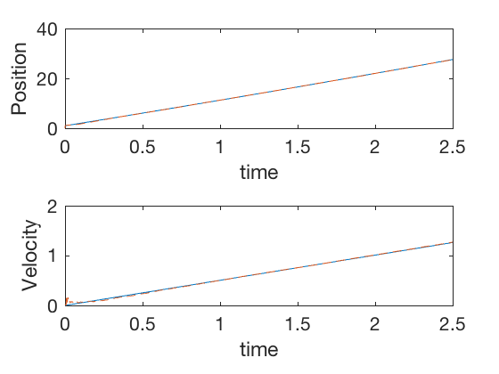

```matlab
figure;
subplot(2,1,1)
plot(t,X(1,:),t,X_hat(1,:),'--')
axis([0 2.5 0 40])
xlabel('time')
ylabel('Position')

subplot(2,1,2)
plot(t,X(2,:),t,X_hat(2,:),'--')
xlabel('time')
ylabel('Velocity')
axis([0 2.5 0 2])
```

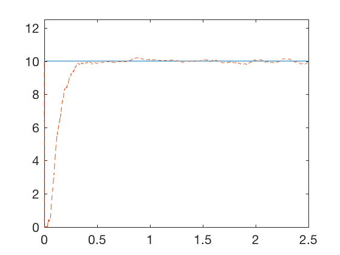

```matlab
figure;
plot(t,X(3,:),t,X_hat(3,:),'--')
axis([0 2.5 0 12.5])
```

## Kalman filter: Continuous system (Kalman-Bucy filter)

Consider the system dynamics given by,

$$ \dot{X} = AX + Bu + Fw $$

where \( w \) is a Gaussian process with zero mean and covariance \( Q \), and measurement given by

$$ y = CX + Du + v $$

The filter for state estimate consists of 2 differential equations,

$$ \dot{\hat{X}} = A \hat{X} + Bu + K ( y - C \hat{X}+ Du) $$

$$ \dot{P} = A P + PA^T + FQF^T - K R K^T$$

$$K = P C^T R^{-1}$$$$ \dot{P} = A P + PA^T + FQF^T - P C^T R CP $$

- In continuous case, the measurement error's covariance and apriori covairance both are \( R \). Further, the observer gain calculations involve taking inverse of the covariance of noise \( R \) matrix.
- The sensor with lower covariance noise will contribute more to the update.
- In the special infitite-time case, the riccati equation becomes,

$$ 0 = A P + PA^T + FQF^T - P C^T R CP $$

### Kalman filter continuous time: Example 6 (two sensors)

- Consider the system, \( \ddot{x} = u \), with measurement on position alone.
- 2 sensors to measure position,
  - one sensor is very accurate (covariance = 0.01),
  - the other is not accurate (covariance = 1).

$$ K_k = \left[ \begin{array}{cc} 0.1090 & 10.8956 \\ 0.0995 & 9.9504 \end{array} \right] $$

```matlab
clc
close all
clear all


A = [0 1;0 0];
B = [0; 1];
C = [1 0;
    1 0];

t = 0:0.001:20;
dt = t(2) - t(1);
X(:,1) = [1;0];
y(:,1) = C*X;
R_k = diag([1 .01]);
Q_k = diag([1 1]);
P_k = care(A',C',Q_k,R_k);
K_k = P_k*C'*inv(R_k);
L = K_k;
K_k
X_hat(:,1) = [0;0];
y_hat(:,1) = C*X_hat;
for i = 2:length(t)
    u = .5;

    X(:,i) = X(:,i-1)  +dt * (A*X(:,i-1) + B*u);
    y(:,i) = C*X(:,i) + sqrt(R_k)*randn(size(C,1),1);

    X_hat(:,i) = X_hat(:,i-1)  +dt * (A*X_hat(:,i-1) + B*u +L *(y(:,i-1)-y_hat(:,i-1)));
    y_hat(:,i) = C*X_hat(:,i) ;
end
```

```
K_k =

    0.1090   10.8956
    0.0995    9.9504
```

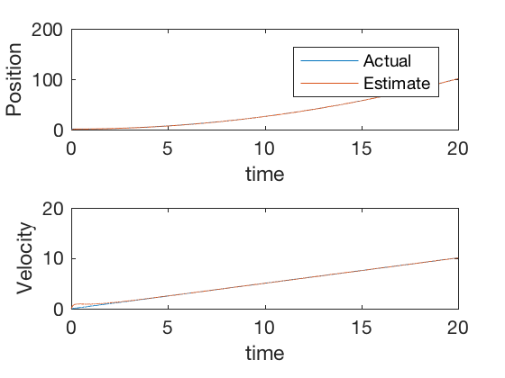

```matlab
figure;
subplot(2,1,1)
plot(t,X(1,:),t,X_hat(1,:))
legend('Actual','Estimate')
xlabel('time')
ylabel('Position')
subplot(2,1,2)
plot(t,X(2,:),t,X_hat(2,:))
xlabel('time')
ylabel('Velocity')
```

### Linear Quadratic Gaussian

- Linear Quadratic Gaussian control is a control scheme that uses [Linear Quadratic Regulator (LQR)](https://mec560sbu.github.io/2016/09/25/Opt_control/) for control and kalman filter (Linear Quadratic Estimation (LQE)) for estimation.
- Separation principle allows to design controller and observer separately

```matlab
clc
close all
clear all


A = [0 1;0 0];
B = [0; 1];
C = [1 0];

% Controller design
R = diag([1]);
Q = diag([1e-2 1e-2]);
M_a = rank(ctrb(A,B));
P = care(A,B,Q,R);
K_u  = inv(R)*B'*P;

t = 0:0.001:20;
dt = t(2) - t(1);
X(:,1) = [1;0];
y(:,1) = C*X;
```

```matlab
% Observer design
R_k = diag([1 ]);
Q_k = diag([1 1]);
P_k = care(A',C',Q_k,R_k);
K_k = P_k*C'*inv(R_k);
L = K_k;

X_hat(:,1) = [0;0];
y_hat(:,1) = C*X_hat;
for i = 2:length(t)
    u = -K_u*X_hat(:,i-1);

    X(:,i) = X(:,i-1)  +dt * (A*X(:,i-1) + B*u);
    y(:,i) = C*X(:,i) + sqrt(R_k)*randn(size(C,1),1);

    X_hat(:,i) = X_hat(:,i-1)  +dt * (A*X_hat(:,i-1) + B*u +L *(y(:,i-1)-y_hat(:,i-1)));
    y_hat(:,i) = C*X_hat(:,i) ;
end
```

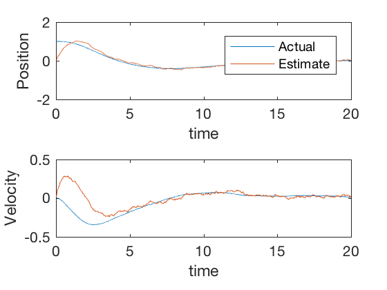

```matlab
figure;
subplot(2,1,1)
plot(t,X(1,:),t,X_hat(1,:))
legend('Actual','Estimate')
xlabel('time')
ylabel('Position')
subplot(2,1,2)
plot(t,X(2,:),t,X_hat(2,:))
xlabel('time')
ylabel('Velocity')
```

### Kalman filter: Conclusion

- Very powerful technique for optimal state estimation
- Extensions for nonlinear filters (extended kalman filter and unscented kalman filter)
- Particle filter (simulation based filters)